# P-values, Null distributions, Omics ranking

[John Zobolas](https://github.com/bblodfon)

Last updated: 16 January, 2023

# On p-values

## Coin Example

**Coin example**: is it fair or not?

```r
knitr::include_graphics(path = 'img/coin.jpeg')
```

[output not shown]

Let’s conduct an experiment => throw $100$ times and count #heads. Let’s say we **observed an extreme $64$ heads**. Do we have enough evidence to say coin if unfair?

4 things to remember when calculating p-values:

1. Null hypothesis $H_0$: **fair coin** (#heads ~ $50$)
2. Test statistic: #heads => distribution (mean $50$?)
3. Compute p-value as:

$Prob(Obs|H_0) = Prob(64 \text{ heads}|H_0:\text{coin is fair})$

4. Decide on significance threshold ($0.05$)

## Simulation

Let’s do a **simulation**:

- Throw $100$ times a fair coin ($H_0$) and count #heads
- Repeat $10000$ times! => make distribution of #heads

```r
set.seed(42)
repeats = 10000
res = sapply(1:repeats, function(num) {
  stat = sample(x = c('heads', 'tails'), replace = T, size = 100)
  sum(stat == 'heads')
})
```

Draw the distribution of #heads:

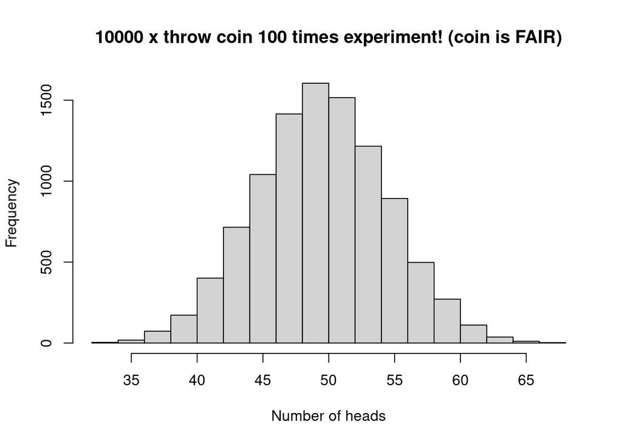

```r
main1 = '10000 x throw coin 100 times experiment! (coin is FAIR)'
hist(res, main = main1, xlab = 'Number of heads')
```

```r
# plot(density(res), main = main1) # smoothed out
```

- The above simulation is formally called *Monte Carlo Random Sampling* [[wiki](https://en.wikipedia.org/wiki/Monte_Carlo_method)]
- This is the **empirical null distribution** of our test statistic (#heads)!

## Empirical p-value

Where does the observation ($64$ heads) ‘sit’ in this distribution?

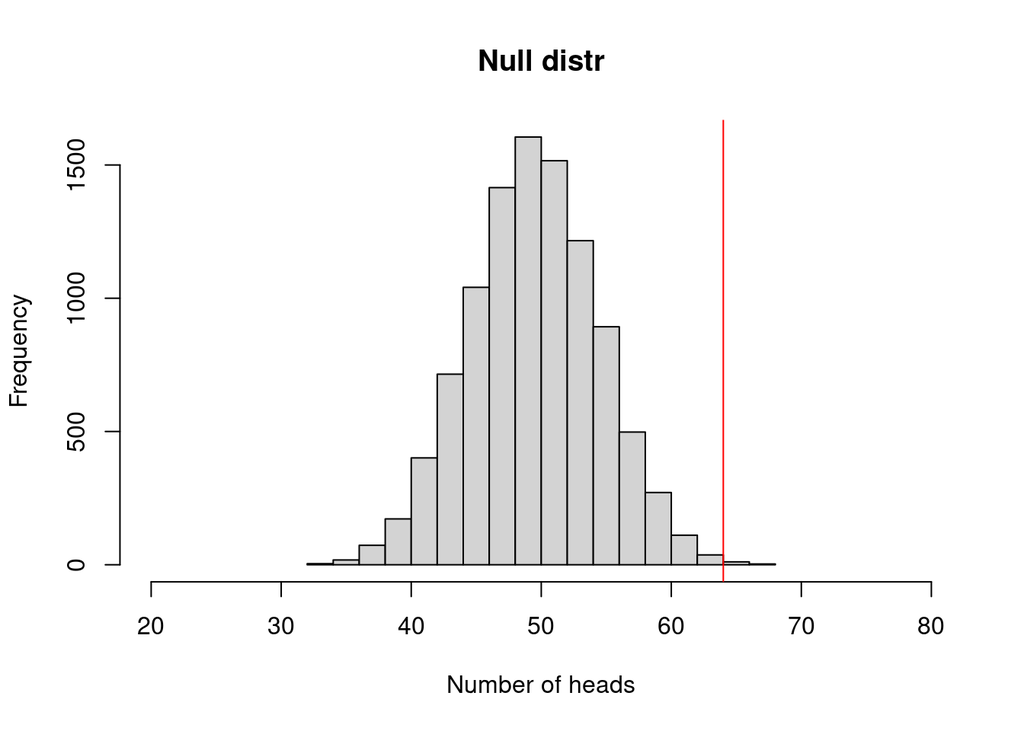

```r
hist(res, xlim = c(20,80), main = 'Null distr', xlab = 'Number of heads')
abline(v = 64, col = 'red')
```

The **empirical p-value** is the proportion of experiments that yielded **equal or more** than the observed #heads ($64$):

```r
p_val = sum(sort(res) >= 64)/length(res) # length(res) = 10000
p_val
```

```
[1] 0.0029
```

Since the above p-value is lower than a predefined threshold (e.g. $0.05$) I can deduce that **the coin is unfair**. More extreme observations would yield smaller p-values, e.g. for #heads = $80$:

```r
sum(sort(res) > 80)/length(res) # length(res) = 10000
```

```
[1] 0
```

## Exact p-value

For this simple example, we could use statistical theory to calculate **exact p-value** (fair coin toss follows *binomial distribution*):

$$P(\text{#heads} \ge 64 | 100 \text{
tosses of a fair coin}) = \\
1 - P(\text{#heads} \le 63)$$

In `R` it’s easy to calculate using the (cumulative) distribution function of the binomial `pbinom`:

```r
1 - pbinom(q = 63, size = 100, prob = 0.5)
```

```
[1] 0.00331856
```

For $80$ heads the p-value can be exactly found now:

```r
1 - pbinom(q = 79, size = 100, prob = 0.5)
```

```
[1] 5.579545e-10
```

# Omics Ranking

## Benchmark Description

```r
ranks = readRDS(file = 'ranks.rds')
```

We have conducted a benchmark as follows:

- We trained and tested several ML models on many datasets
- The datasets are **dependent** (different omic combinations)
  - All single omics: mRNA, miRNA, Clinical, etc.
  - All pairs of omics: Clinical + mRNA, miRNA + mRNA
  - All triplets and so on… (*powerset* = **every possible omic (feature type) combination**)
- **Performance measure**: C-index (higher is better)
  - We take the median C-index across $1000$ bootstrap resamples of the test set

E.g. for the `CoxNet` model the performance across all omic combinations is:

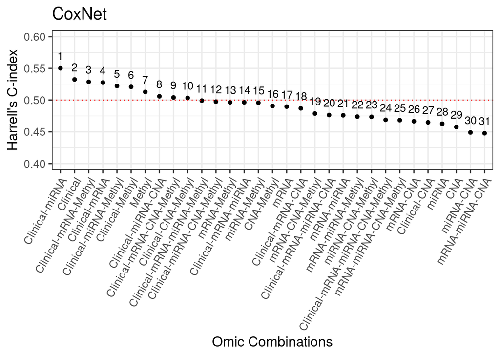

```r
coxnet_scores =
  ranks$mat['coxnet',] %>%
  tibble::enframe(name = 'Task', value = 'Cindex') %>%
  mutate(Task = forcats::fct_reorder(Task, Cindex, .desc = TRUE))

coxnet_scores %>%
  ggplot(aes(x = Task, y = Cindex)) +
    geom_point() +
    geom_hline(yintercept = 0.5, linetype = 'dotted', color = 'red') +
    labs(x = 'Omic Combinations', y = 'Harrell\'s C-index', title = 'CoxNet') +
    ylim(c(0.4,0.6)) +
    geom_text(aes(label = rank(-Cindex)), hjust = 0.5, vjust = -1) +
    theme_bw(base_size = 14) +
    theme(axis.text.x = element_text(angle = 60, hjust = 1))
```

## The task

Can I define a **statistic/score** per omic that will tell me *how important* that particular omic is (and *strength of importance* with the p-value)?

How to define *importance* in the above context?

## Rank-Sum score

### Deriving the score

Let’s use some toy data with $3$ omics and all combos ($2^3 - 1 = 7$) - why not $8$?:

```r
set1 = LETTERS[1:3]
set1
```

```
[1] "A" "B" "C"
```

```r
get_subsets = function(set) {
  lapply(1:length(set), combinat::combn, x = set, simplify = FALSE) %>%
  unlist(recursive = FALSE) %>%
  lapply(function(sub_set) {
    paste0(sub_set, collapse = '-')
  }) %>%
  unlist(use.names = FALSE)
}

subsets = get_subsets(set1)
subsets
```

```
[1] "A"     "B"     "C"     "A-B"   "A-C"   "B-C"   "A-B-C"
```

How many times every omic appears in the above list? For $n$ omics?

```r
# Answer: $2^{(n-1)}$
# In the example: n = 3 => 2^2 = 4 times
```

Example rankings - 3 x same figure, change color if omic combo has:

- A
- B
- C

```r
set.seed(42)
scores = rnorm(1:7, mean = 0.5, sd = 0.1)
tbl = tibble(Task = subsets, meas = scores) %>%
      mutate(Task = forcats::fct_reorder(Task, meas, .desc = TRUE))

p = tbl %>%
  ggplot(aes(x = Task, y = meas)) +
    geom_point(size = 3) +
    geom_hline(yintercept = 0.5, linetype = 'dotted', color = 'red') +
    labs(x = 'Omic Combinations', y = 'Harrell\'s C-index', title = 'Toy Example') +
    ylim(c(0.4,0.7)) +
    geom_text(aes(label = rank(-meas)), size = 10, hjust = 0.5, vjust = -1) +
    theme_bw(base_size = 20)
```

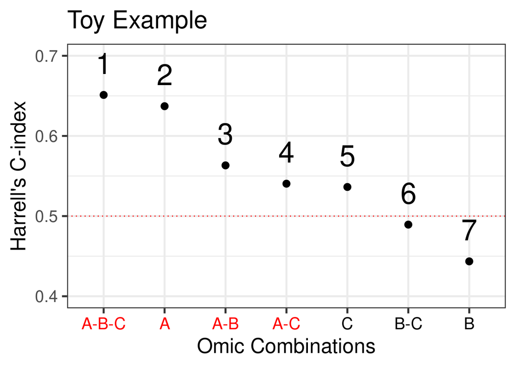

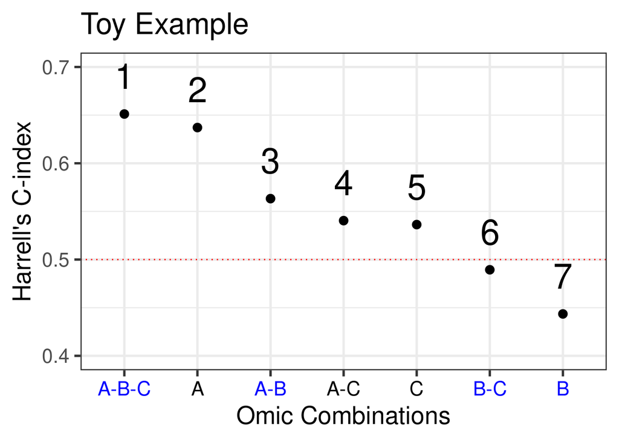

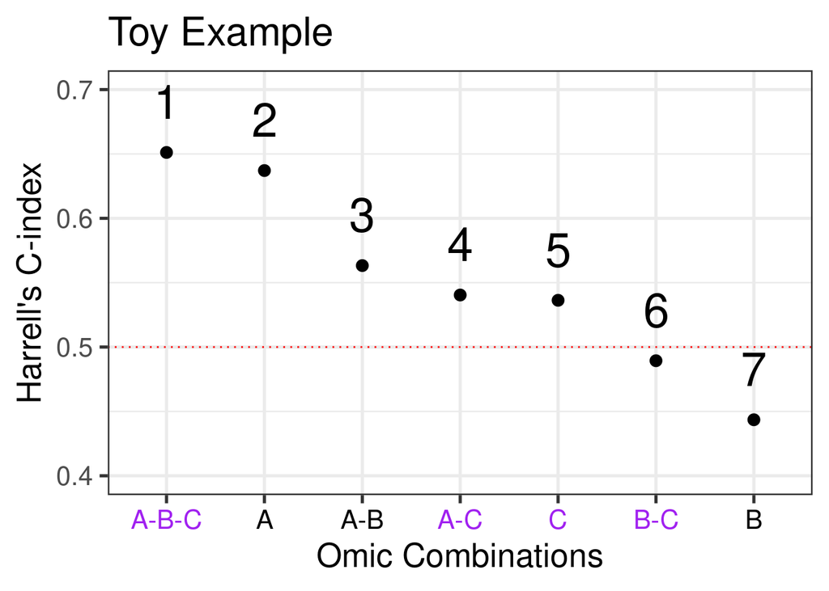

```r
mycol1 = ifelse(grepl(pattern = 'A', x = levels(tbl$Task)), 'red', 'black')
mycol2 = ifelse(grepl(pattern = 'B', x = levels(tbl$Task)), 'blue', 'black')
mycol3 = ifelse(grepl(pattern = 'C', x = levels(tbl$Task)), 'purple', 'black')

# A more important
p + theme(axis.text.x = element_text(color = mycol1))
# B next
p + theme(axis.text.x = element_text(color = mycol2))
# C last
p + theme(axis.text.x = element_text(color = mycol3))
```

A more important omic will be in more combos **towards the left** of the above figures!

Let’s define based on the *more left*-idea!

Define as score the **sum of ranks (the lower the better)**:

Worst score would be?

- $4$ most-right ranks => $4+5+6+7=22$  
  I can easily **normalize** the score so that best possible value becomes $1$ and worst possible $0$, as:

$$score = 1 - \frac{sum(ranks) -
best(score)}{worst(score) - best(score)}$$

Therefore we have:

- `A`: $score = 1 - \frac{10 - 10}{22 - 10}=1$
- `B`: $score = 1 - \frac{17 - 10}{22 - 10}=0.41$
- `C`: $score = 1 - \frac{16 - 10}{22 - 10}=0.5$

### Get a p-value

- **How high** needs this score to be to be actually important?
- How to construct the **null distribution** of our derived score/statistic and get an empirical p-value?

Observation: every omic in the toy example will take $4$ values from the below rankings:

```r
nomics = 3
ranks = 1:(2^nomics-1)
ranks
```

```
[1] 1 2 3 4 5 6 7
```

We just need to randomly select $4$ of these and add them (+normalization step) to get a possible rank-sum score. Of course we will repeat this procedure **multiple times**:

```r
nsets = 2^(nomics-1) # 4

# smaller possible rank sum (all left ranks)
best_rs  = sum(1:2^(nomics-1)) # 10
# larger possible rank sum (all right ranks)
worst_rs = sum(seq(to = 2^nomics-1, length.out = 2^(nomics-1))) # 22

# generate null dist - same for each omic
# use simple Monte Carlo random sampling
set.seed(42)
nsamples = 1000
null_nrs = sapply(1:nsamples, function(s) {
  rank_sum = sum(sample(x = ranks, size = nsets, replace = FALSE))
  1 - (rank_sum - best_rs)/(worst_rs - best_rs)
})
```

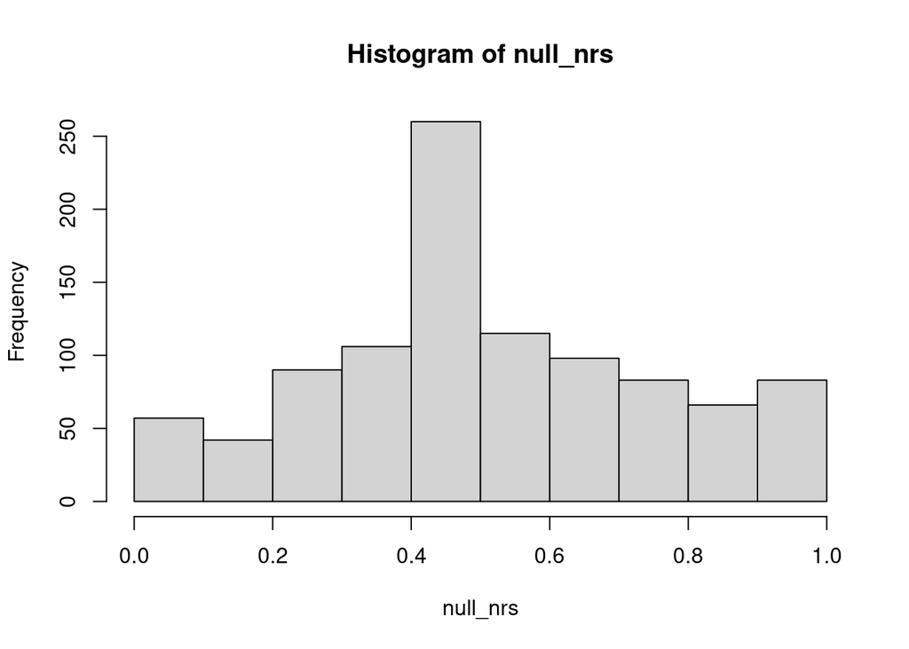

```r
hist(null_nrs)
```

`A` omic is important at the $0.05$ significance level:

```r
scoreA = 1
pval_A = (sum(null_nrs >= scoreA)+1)/(length(null_nrs)+1)
pval_A
```

```
[1] 0.03996004
```

```r
scoreB = 0.41
pval_B = (sum(null_nrs >= scoreB)+1)/(length(null_nrs)+1)
pval_B
```

```
[1] 0.7052947
```

```r
scoreC = 0.5
pval_C = (sum(null_nrs >= scoreC)+1)/(length(null_nrs)+1)
pval_C
```

```
[1] 0.5864136
```

Another hypothetical example with a $score = 0.92$:

```r
score = 0.92
pval = (sum(null_nrs >= score)+1)/(length(null_nrs)+1)
pval
```

```
[1] 0.03996004
```

- Discuss importance of number of omics $n$ (the more the better!)

**Unique scores** in the null distribution very few:

```r
unique(null_nrs)
```

```
 [1] 0.25000000 0.33333333 0.41666667 0.50000000 1.00000000 0.91666667
 [7] 0.16666667 0.58333333 0.83333333 0.00000000 0.66666667 0.75000000
[13] 0.08333333
```